### Heated path

Plot leap-frog steps with associated temperatures:

```r
library(tidyverse)
```

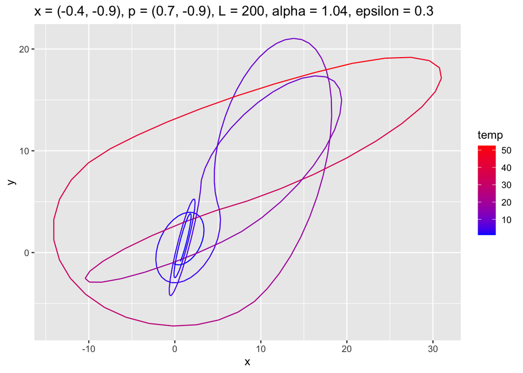

```r
library(mvtnorm)
path <- read.csv("./sim_output/path1.csv")
path %>%
    ggplot(aes(x = x, y = y, color = temp)) +
    ggtitle("x = (-0.4, -0.9), p = (0.7, -0.9), L = 200, alpha = 1.04, epsilon = 0.3") +
    geom_path() + scale_color_gradient(low = "blue", high = "red")
```

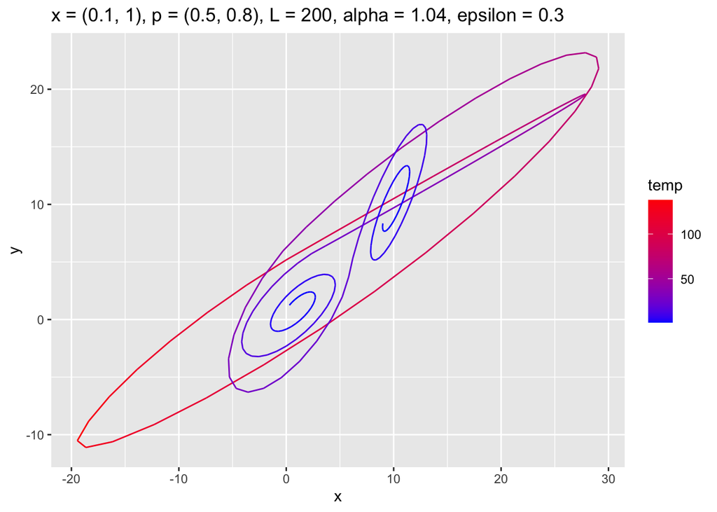

```r
path <- read.csv("./sim_output/path2.csv")
path %>%
    ggplot(aes(x = x, y = y, color = temp)) +
    ggtitle("x = (0.1, 1), p = (0.5, 0.8), L = 200, alpha = 1.04, epsilon = 0.3") +
    geom_path() + scale_color_gradient(low = "blue", high = "red")
```

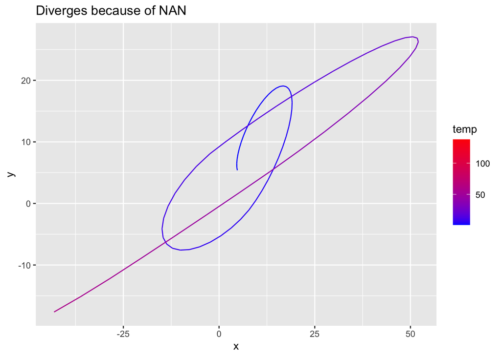

```r
path <- read.csv("./sim_output/path3.csv")
path %>%
    ggplot(aes(x = x, y = y, color = temp)) +
    ggtitle("Diverges because of NAN") +
    geom_path() + scale_color_gradient(low = "blue", high = "red")
```

Turns out when the temperature gets too high, (q) may wander to coordinates with very low density, making the gradient NaN (as f(x) goes to 0) There are two ways to handle this:

```
1. Take the next sample to be the current one (as the new proposal is unlikely to be accepted anyway)
2. Change the functions scale to log (tricky but more "correct") - turns out this is not feasible
```

### Tempered transitioning HMC

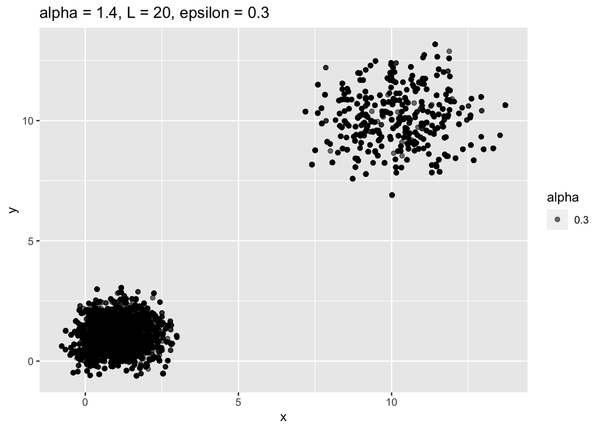

```r
cov1 <- diag(c(1, 1))
cov2 <- diag(c(2, 2))
covs <- list(cov1, cov2)

means <- list(c(1, 1), c(10, 10))
weights <- c(0.5, 0.5)

params <- list("means" = means, "covs" = covs,
               "num_steps" = 200,
               "step_size" = 0.3,
               "alpha" = 1.04,
               "mass" = diag(c(1, 1)))

# samples <- get_samples(c(2, 2), params, weights, n_samples = 10000)
samples <- read.csv("./sim_output/far_modes_hmc_1.4.csv")
samples %>%
    ggplot(aes(x = x, y = y, alpha = 0.3)) + geom_point() + ggtitle("alpha = 1.4, L = 20, epsilon = 0.3")
```

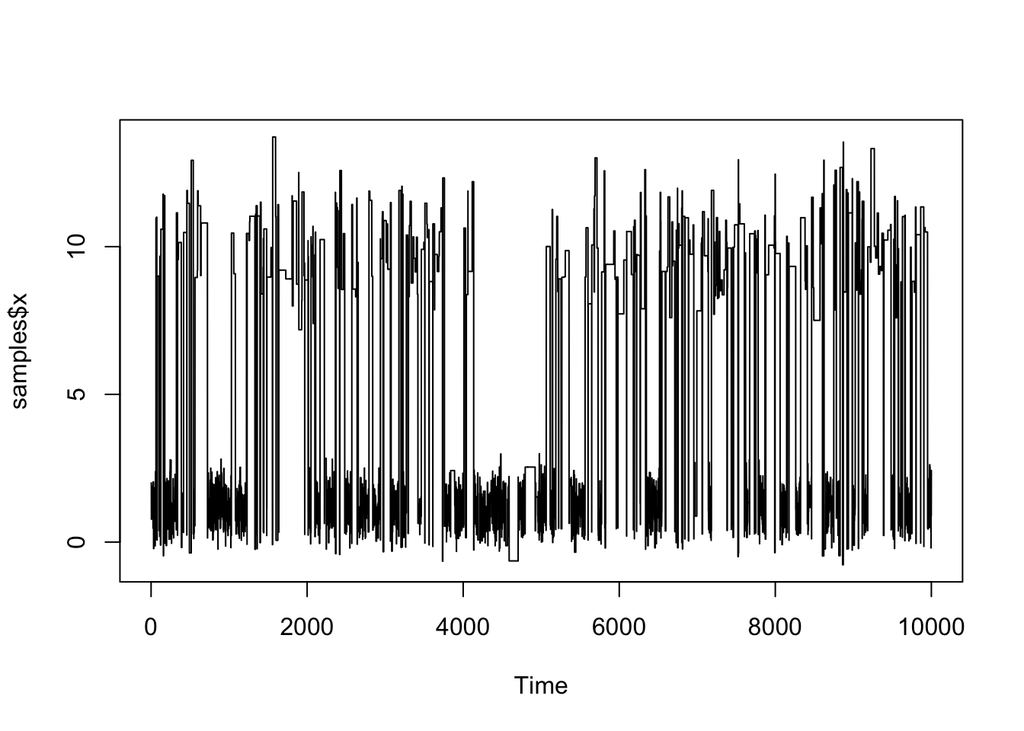

```r
ts.plot(samples$x)
```

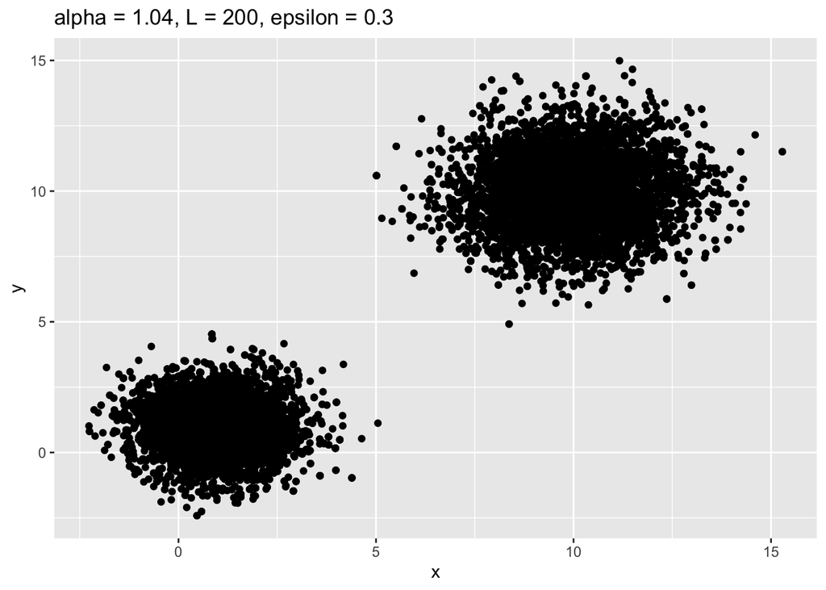

```r
samples <- read.csv("./sim_output/far_modes_hmc_1.04.csv")
samples %>%
    ggplot(aes(x = x, y = y)) + geom_point() + ggtitle("alpha = 1.04, L = 200, epsilon = 0.3")
```

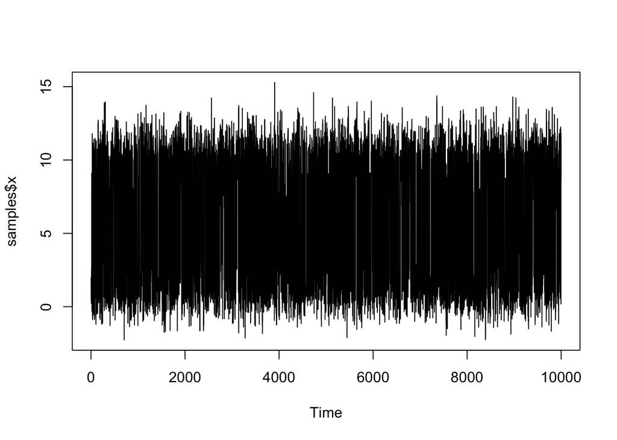

```r
ts.plot(samples$x)
```

### Target raised to a temperature

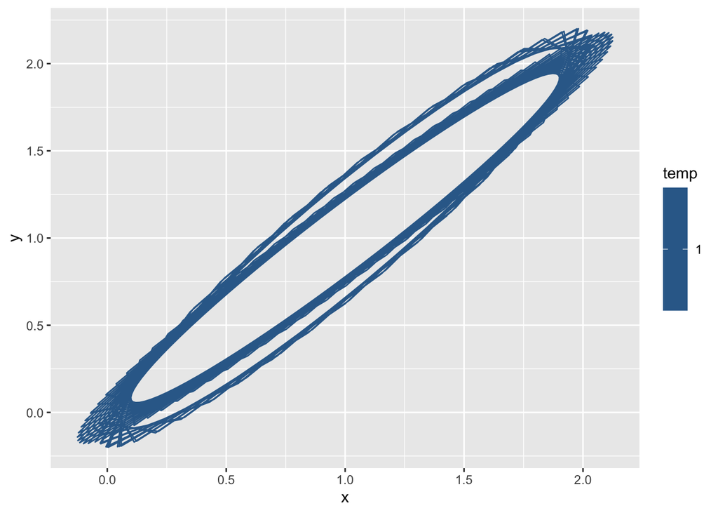

```r
# T <- c(2, 4, 8, 16, 32)
cov1 <- diag(c(1, 1)) / T
cov2 <- diag(c(2, 2)) / T
covs <- list(cov1, cov2)

means <- list(c(1, 1), c(10, 10))
weights <- c(0.5, 0.5)

params <- list("means" = means, "covs" = covs,
               "num_steps" = 200,
               "step_size" = 0.3,
               "alpha" = 1.0,
               "mass" = diag(c(1, 1)))

path <- read.csv("./sim_output/path_temp_16.csv")
path %>% ggplot(aes(x = x, y = y, color = temp)) + geom_path()
```

Changing the mass matrix to diag(c(3, 3)): not much better My guess is that as the distribution gets flatter, its gradient reduces in magnitude across the board and limit the movement range of the particle.

Perhaps increasing the step_size would help ? But if that is the case then shouldn’t tempered transitioning be used ?

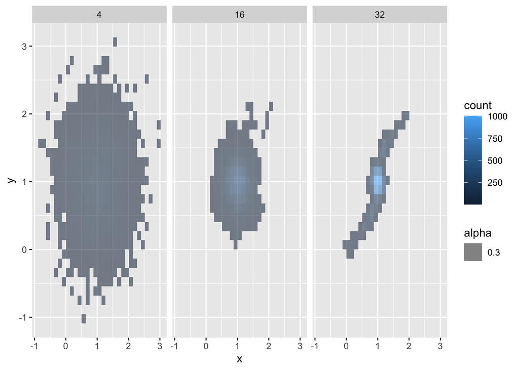

```r
samples <- read.csv("./sim_output/distant_modes_temps.csv")
samples %>%
    ggplot(aes(x = x, y = y, alpha = 0.3)) + geom_bin2d() + facet_wrap(~temp)
```

### HMC within Gibbs framework

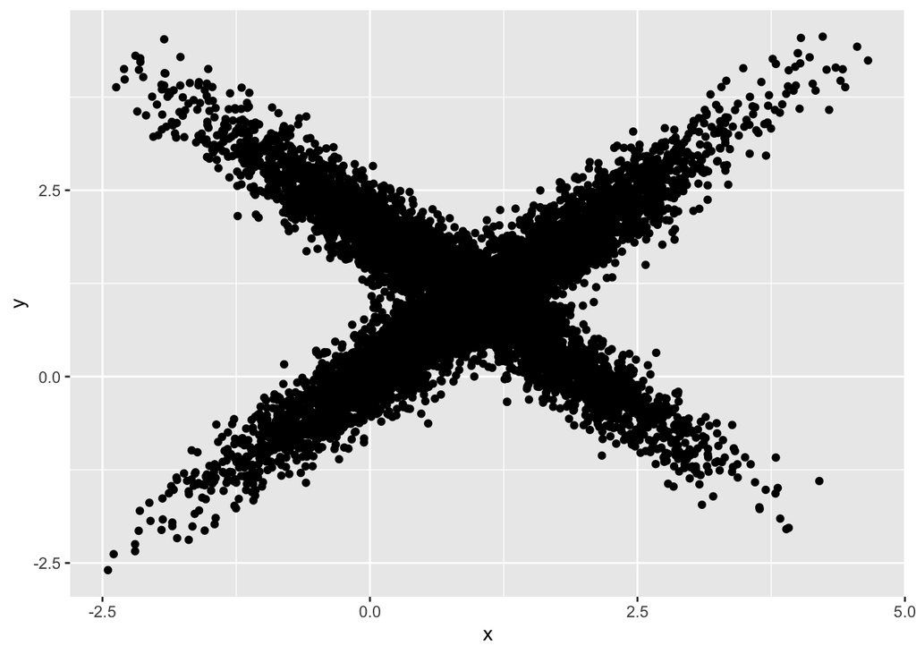

```r
cov1 <- matrix(c(1, 0.95, 0.95, 1), nrow = 2, byrow = TRUE)
cov2 <- matrix(c(1, -0.95, -0.95, 1), nrow = 2, byrow = TRUE)

covs <- list(cov1, cov2)
means <- list(c(1, 1), c(1, 1))

params <- list("means" = means, "covs" = covs,
               "num_steps" = 10,
               "step_size" = 0.05,
               "alpha" = 1,
               "mass" = diag(c(1, 1)))
class(params) <- "HMC_sim_parameters"

# moved sampling from R to C++ for faster performance
df <- read.csv("./sim_output/correlated_target_n_HMC.csv")
df %>%
    ggplot(aes(x = x, y = y)) + geom_point()
```